# Section 11: One-Sample Proportion Inference

```r
library(tidyverse)
```

## Proportion sampling distribution

This lecture will use the data in `chimpanzee.csv`. The data is based on an experiment conducted by scientists at Emory University in 2011; though those scientists did not make their true data public, we have created a “mock” dataset which gives the same results and summary values as their data.

- Two chimpanzees were put in adjacent enclosures with the ability to see and communicate with each other.
- One chimpanzee, the **actor**, was given the choice to pick from a bucket of tokens which were two different colors.
- The actor had previously been taught that one color would lead to the human researcher to give them (just the actor) a treat. We call this the **selfish** choice.
- The other color would lead to the human researcher giving **both the actor and the partner** a treat. We call this the “**prosocial**” choice.
- The **actor** was given this choice 30 times, and the number of **prosocial** and **selfish** choices were recorded.
- The researchers performed this experiment with many combinations of actors, partners, and colors; including observing their behavior when the actor had **no partner**.
- Our “mock” dataset for this can be found in `chimpanzee.csv`. Each row is a combination of actor and partner

```r
chimpanzee <- read_csv("../../data/chimpanzee.csv")
head(chimpanzee)
```

```
## # A tibble: 6 × 6
##   actor partner prosocial selfish prosocial_color selfish_color
##   <chr> <chr>       <dbl>   <dbl> <chr>           <chr>
## 1 A     I              22       8 green           purple
## 2 A     G              16      14 yellow          black
## 3 A     H              22       8 blue            red
## 4 A     none           16      14 pink            gray
## 5 B     H              18      12 black           yellow
## 6 B     C              23       7 purple          green
```

Let’s exploree the data.

```r
sum1 <- chimpanzee %>%
  mutate(session_type = case_when(
    partner == "none" ~ "no partner",
    TRUE ~ "partner"
  )) %>%
  group_by(actor, session_type) %>%

  summarize(prosocial = sum(prosocial),
            selfish = sum(selfish),
            n = prosocial + selfish,
            p_hat = prosocial/n)
sum1
```

```
## # A tibble: 13 × 6
## # Groups:   actor [7]
##    actor session_type prosocial selfish     n p_hat
##    <chr> <chr>            <dbl>   <dbl> <dbl> <dbl>
##  1 A     no partner          16      14    30 0.533
##  2 A     partner             60      30    90 0.667
##  3 B     no partner          16      14    30 0.533
##  4 B     partner             60      30    90 0.667
##  5 C     no partner          17      13    30 0.567
##  6 C     partner             57      33    90 0.633
##  7 D     no partner           8      22    30 0.267
##  8 D     partner             50      40    90 0.556
##  9 E     no partner          12      18    30 0.4
## 10 E     partner             48      42    90 0.533
## 11 F     no partner          14      16    30 0.467
## 12 F     partner             47      43    90 0.522
## 13 G     partner             37      33    70 0.529
```

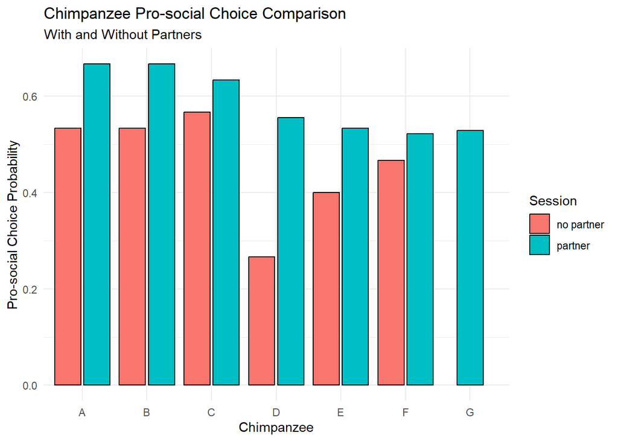

```r
ggplot(sum1, aes(x = actor, y = p_hat,
                 fill = session_type)) +
  geom_col(color = "black",
           position = position_dodge2(preserve = "single")) +
  #scale_y_continuous(labels = percent_format(scale = 1)) +
  labs(
    x = "Chimpanzee",
    y = "Pro-social Choice Probability",
    title = "Chimpanzee Pro-social Choice Comparison",
    subtitle = "With and Without Partners",
    fill = "Session"
  ) +
  theme_minimal()
```

Let’s simulate the observed number of prosocial choices in 90 trials, if $p = 0.6$.

```r
# simulation parameters
B <- 10000
n <- 90
p <- 0.6

# One example of an experiment
rbinom(1, n, p)
```

```
## [1] 57
```

```r
# do the simulation 10000 times
sim <- tibble(
  x_star = rbinom(B, n, p),
  p_hat = x_star / n)
```

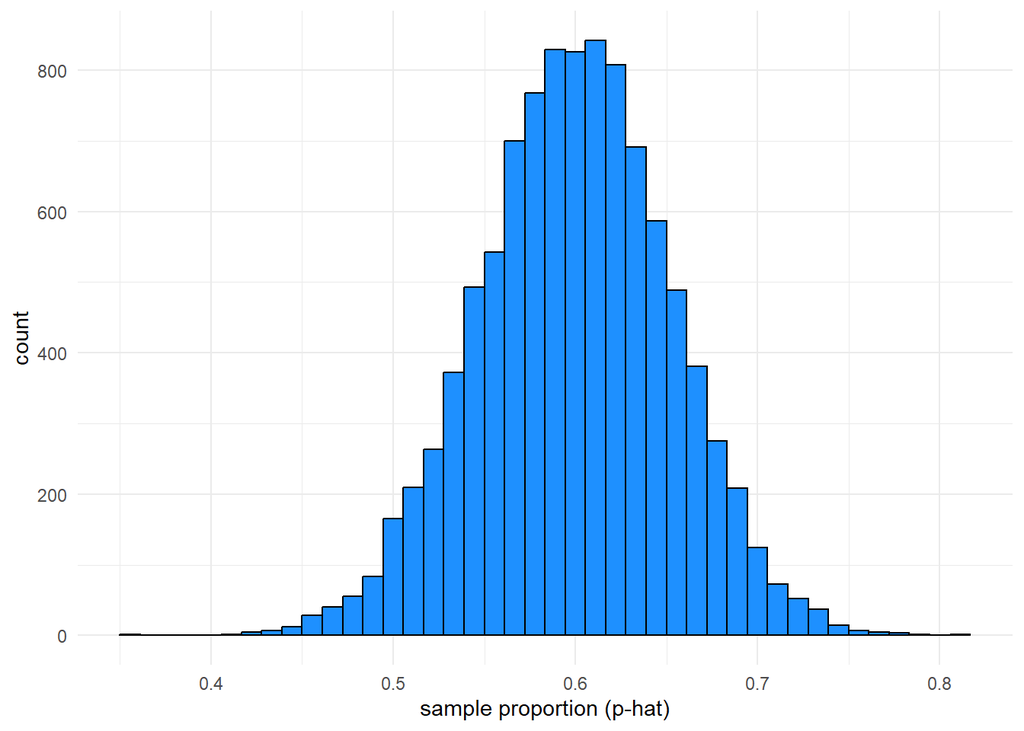

```r
# Graphical summary
ggplot(sim, aes(x = p_hat)) +
  geom_histogram(binwidth = 1/90,
                 color = "black", fill = "dodgerblue") +
  xlab("sample proportion (p-hat)") +
  theme_minimal()
```

```r
# Numeric summary
sim_summary <- sim %>%
  summarize(mean = mean(p_hat),  ## this should be very close to 0.6
            sd = sd(p_hat)) ## this should be very close to 0.0516
sim_summary
```

```
## # A tibble: 1 × 2
##    mean     sd
##   <dbl>  <dbl>
## 1 0.599 0.0525
```

The sampling distribution of p-hat has a normal shape, and its mean is very close to $p = 0.6$.

### Try it out

Recreate the simulation but use $n = 30$ and $p = 0.2$ instead. What do you notice about the shape of the sampling distribution?

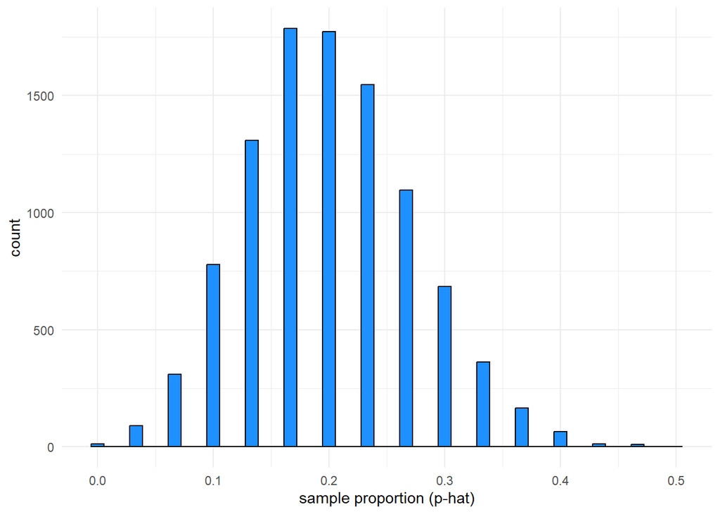

```r
# simulation parameters
B <- 10000
n <- 30
p <- 0.2


# do the simulation 10000 times
sim <- tibble(
  x_star = rbinom(B, n, p),
  p_hat = x_star / n)

# Graphical summary
ggplot(sim, aes(x = p_hat)) +
  geom_histogram(binwidth = 1/90,
                 color = "black", fill = "dodgerblue") +
  xlab("sample proportion (p-hat)") +
  theme_minimal()
```

```r
# Numeric summary
sim_summary <- sim %>%
  summarize(mean = mean(p_hat),  ## this should be very close to 0.6
            sd = sd(p_hat)) ## this should be very close to 0.0516
sim_summary
```

```
## # A tibble: 1 × 2
##    mean     sd
##   <dbl>  <dbl>
## 1 0.200 0.0725
```

## Confidence interval for p

Let’s build a 90% CI for $P_{A, partner}$. For 90% confidence (alpha = 0.1), use the 95th or 5th percentile.

```r
qnorm(0.05)
```

```
## [1] -1.644854
```

```r
qnorm(0.95)
```

```
## [1] 1.644854
```

A 90% CI for $p_{A, partner}$ is

```r
n <- 90
x <- 60
p_hat <- x/n

se <- sqrt(p_hat * (1 - p_hat) / n)

cv <- qnorm(0.95)


c(p_hat - cv*se, p_hat + cv*se)
```

```
## [1] 0.5849332 0.7484001
```

## Hypothesis test for p

We want to test whether chimpanzee A makes prosocial choices with a rate greater than 0.5. The null distribution is Binom(90, 0.5) and the test statistic is 60.

The p-value is $P(Binom(90, 0.5) \ge 60)$

```r
1 - pbinom(59, 90, 0.5)
```

```
## [1] 0.001030133
```

### Try it out

```r
sum1_partner <- sum1 %>%
  filter(session_type == "partner")

# Overall prosocial rate with a partner
sum(sum1_partner$prosocial) / sum(sum1_partner$n)
```

```
## [1] 0.5885246
```

Chimpanzee F has the lowest observed prosocial-partner rate of 47/90. Is the true rate significantly *less* than the average of 0.59?

```r
pbinom(47, 90, 0.59)
```

```
## [1] 0.1154698
```

### Psychic example

Now consider a two-sided hypothesis.

The outcomes 60 and above are less likely (more extreme, more evidence against H0) as 47.

```r
dbinom(47, 90, 0.59)
```

```
## [1] 0.03613033
```

```r
tibble(
  x = 56:65,
  prob = dbinom(x, 90, 0.59),
  lessThanP47 = prob < dbinom(47, 90, 0.59)
)
```

```
## # A tibble: 10 × 3
##        x    prob lessThanP47
##    <int>   <dbl> <lgl>
##  1    56 0.0712  FALSE
##  2    57 0.0611  FALSE
##  3    58 0.0500  FALSE
##  4    59 0.0390  FALSE
##  5    60 0.0290  TRUE
##  6    61 0.0205  TRUE
##  7    62 0.0138  TRUE
##  8    63 0.00884 TRUE
##  9    64 0.00537 TRUE
## 10    65 0.00309 TRUE
```

The two-sided p-value includes the outcomes less than or equal to 47 AND those greater than or equal to 60.

```r
pbinom(47, 90, 0.59) + (1 - pbinom(60 - 1, 90, 0.59))
```

```
## [1] 0.1994635
```

# Normal approximation

Let’s repeat the two-sided test with a Z test. First check: is a normal approximation valid?

```r
# Estimate np(1-p), check if greater than 10
90*0.59*0.41
```

```
## [1] 21.771
```

P-value calculation:

```r
pnorm(-1.31) + pnorm(1.31, lower.tail = F)
```

```
## [1] 0.1901958
```

```r
# or
2*pnorm(-1.31)
```

```
## [1] 0.1901958
```

We can also use a rejection region approach. The two-sided rejection region splits $\alpha = 0.05$ into the tails of the normal.

```r
qnorm(0.025)
```

```
## [1] -1.959964
```

```r
qnorm(0.975)
```

```
## [1] 1.959964
```

Our test statistic falls between these values.